# Summary Statistics with R

Sara Geremia

2024-03-21

The summary function gives some useful statistics for vectors, matrices, factors, and data frames:

```r
vec <- sample(1:20, 10, replace = TRUE)
summary(vec)
```

```
##    Min. 1st Qu.  Median    Mean 3rd Qu.    Max.
##    2.00    5.50    8.50   10.30   16.25   18.00
```

The summary of a matrix works column by column. Here we see the summary of a matrix, mat, with three columns named s1, s2, and s3

```r
s1 <- sample(1:20, 10, replace = TRUE)
s2 <- sample(1:20, 10, replace = TRUE)
s3 <- sample(1:20, 10, replace = TRUE)

mat <- cbind(s1, s2, s3)
summary(mat)
```

```
##        s1              s2              s3
##  Min.   : 1.00   Min.   : 2.00   Min.   : 1.00
##  1st Qu.: 6.25   1st Qu.: 5.75   1st Qu.: 3.00
##  Median :16.00   Median :12.00   Median :10.00
##  Mean   :12.20   Mean   :10.90   Mean   :10.00
##  3rd Qu.:16.00   3rd Qu.:16.00   3rd Qu.:14.75
##  Max.   :20.00   Max.   :18.00   Max.   :20.00
```

The summary of a factor gives counts:

```r
weather <- factor(c("Sunny", "Rainy", "Cloudy", "Sunny", "Rainy"))
summary(weather)
```

```
## Cloudy  Rainy  Sunny
##      1      2      2
```

The summary of a data frame incorporates all these features. It works column by column, giving an appropriate summary according to the column type. Numeric values receive a statistical summary and factors are counted (character strings are not summarized)

```r
names <- c("John", "Jane", "Frank", "Mike", "Alice")
numbers <- 1:5
logical_vals <- c(TRUE, FALSE, FALSE, FALSE, TRUE)

df <- data.frame(name = names, id = numbers, gender = logical_vals, weather = weather)

summary(df)
```

```
##      name                 id      gender          weather
##  Length:5           Min.   :1   Mode :logical   Cloudy:1
##  Class :character   1st Qu.:2   FALSE:3         Rainy :2
##  Mode  :character   Median :3   TRUE :2         Sunny :2
##                     Mean   :3
##                     3rd Qu.:4
##                     Max.   :5
```

Load data

```r
load("practice/01-Descriptive/data/milan_egypop.RData")
```

```r
str(milan_egypop)
```

```
## spc_tbl_ [148,582 × 7] (S3: spec_tbl_df/tbl_df/tbl/data.frame)
##  $ year  : Factor w/ 25 levels "1999","2000",..: 1 1 1 1 1 1 1 1 1 1 ...
##  $ id_nil: Factor w/ 85 levels "1","2","4","5",..: 1 1 1 1 1 1 1 1 1 1 ...
##  $ nil   : Factor w/ 85 levels "Adriano","Affori",..: 22 22 22 22 22 22 22 22 22 22 ...
##  $ age   : num [1:148582] 0 10 14 15 17 20 26 27 3 31 ...
##  $ gender: Factor w/ 2 levels "Femmine","Maschi": 1 1 1 2 2 2 1 1 2 2 ...
##  $ nat   : Factor w/ 1 level "Egitto": 1 1 1 1 1 1 1 1 1 1 ...
##  $ inhab : num [1:148582] 1 1 1 1 1 1 1 1 1 1 ...
##  - attr(*, "spec")=
##   .. cols(
##   ..   Anno = col_double(),
##   ..   IdNil = col_double(),
##   ..   Nil = col_character(),
##   ..   Eta = col_character(),
##   ..   Genere = col_character(),
##   ..   Cittadinanza = col_character(),
##   ..   Residenti = col_double()
##   .. )
##  - attr(*, "problems")=<externalptr>
```

```r
summary(milan_egypop$age)
```

```
##    Min. 1st Qu.  Median    Mean 3rd Qu.    Max.
##     0.0    14.0    30.0    30.2    44.0   101.0
```

- **Base-R**

Compute the weighted mean age

```r
sum(milan_egypop$age * milan_egypop$inhab) / sum(milan_egypop$inhab)
```

```
## [1] 29.33464
```

```r
weighted.mean(milan_egypop$age, milan_egypop$inhab)
```

```
## [1] 29.33464
```

Compute the weighted mean age by gender

```r
milan_egypop_m <- milan_egypop[milan_egypop$gender == "Maschi", ]
milan_egypop_f <- milan_egypop[milan_egypop$gender != "Maschi", ]

weighted.mean(milan_egypop_m$age, milan_egypop_m$inhab)
```

```
## [1] 31.85738
```

```r
weighted.mean(milan_egypop_f$age, milan_egypop_f$inhab)
```

```
## [1] 22.57884
```

- **Tidyverse**

```r
# weighted mean
milan_egypop %>%
  summarise(mean_age = weighted.mean(age, inhab))
```

```
## # A tibble: 1 × 1
##   mean_age
##      <dbl>
## 1     29.3
```

```r
# conditional mean
milan_egypop %>%
  group_by(gender) %>%
  summarise(mean_age = weighted.mean(age, inhab))
```

```
## # A tibble: 2 × 2
##   gender  mean_age
##   <fct>      <dbl>
## 1 Femmine     22.6
## 2 Maschi      31.9
```

## Box Plot

- **Base-R**

Create a box plot for age

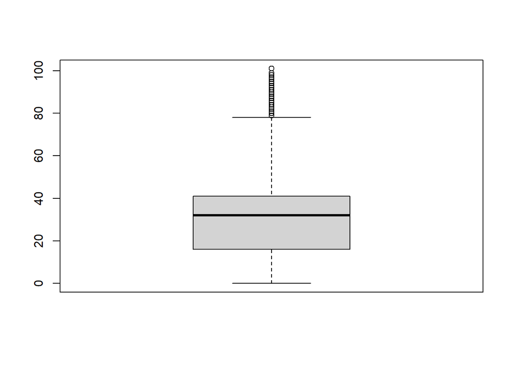

```r
milan_egypop_age <- rep(milan_egypop$age, milan_egypop$inhab)
boxplot(milan_egypop_age)
```

- **Tidyverse**

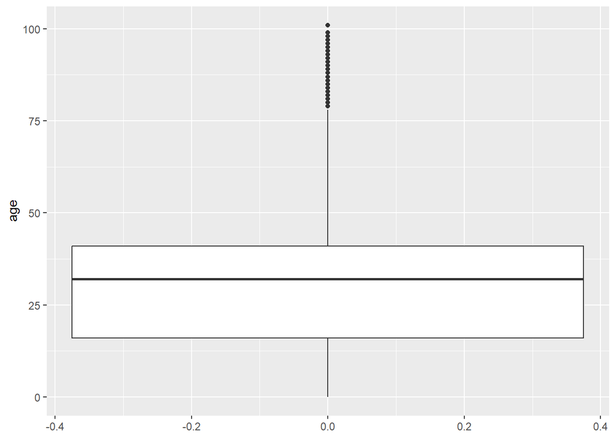

```r
milan_egypop_age <- bind_cols(age = rep(milan_egypop$age, milan_egypop$inhab),
          gender = rep(milan_egypop$gender, milan_egypop$inhab))

milan_egypop_age %>%
  ggplot(aes(y = age)) +
  geom_boxplot()
```

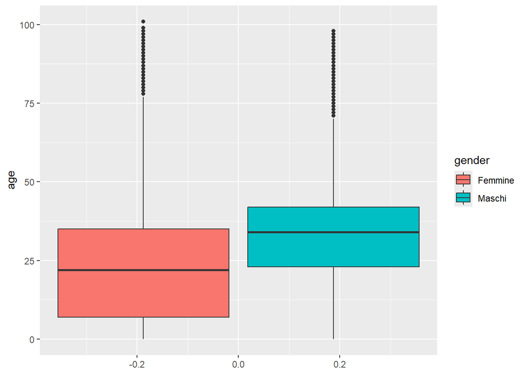

```r
milan_egypop_age %>%
  ggplot(aes(y = age, fill = gender)) +
  geom_boxplot()
```

Compute the variance

```r
var(milan_egypop_age$age)
```

```
## [1] 258.2055
```

```r
milan_egypop_age %>%
  group_by(gender) %>%
  summarise(var = var(age))
```

```
## # A tibble: 2 × 2
##   gender    var
##   <fct>   <dbl>
## 1 Femmine  271.
## 2 Maschi   230.
```